# Ford Gobike 2017 Data Exploratory Analysis

Import all required libraries

```python
# import all packages and set plots to be embedded inline
import numpy as np
import pandas as pd
import matplotlib.pyplot as plt
import seaborn as sb

import warnings
warnings.filterwarnings('ignore')

%matplotlib inline
```

read the 2017 ford gobike data-set

```python
data = pd.read_csv('2017-fordgobike-tripdata.csv')
```

print the data-set shape and the columns names

```python
# high-level overview of data shape and composition
print(data.shape)
print(data.dtypes)
```

```
(519700, 13)
duration_sec                 int64
start_time                  object
end_time                    object
start_station_id             int64
start_station_name          object
start_station_latitude     float64
start_station_longitude    float64
end_station_id               int64
end_station_name            object
end_station_latitude       float64
end_station_longitude      float64
bike_id                      int64
user_type                   object
dtype: object
```

Take a look for thr first 5 rows of the data-set

```python
data.head(5)
```

|  | duration_sec | start_time | end_time | start_station_id | start_station_name | start_station_latitude | start_station_longitude | end_station_id | end_station_name | end_station_latitude | end_station_longitude | bike_id | user_type |
| --- | --- | --- | --- | --- | --- | --- | --- | --- | --- | --- | --- | --- | --- |
| 0 | 80110 | 2017-12-31 16:57:39.6540 | 2018-01-01 15:12:50.2450 | 74 | Laguna St at Hayes St | 37.776435 | -122.426244 | 43 | San Francisco Public Library (Grove St at Hyde... | 37.778768 | -122.415929 | 96 | Customer |
| 1 | 78800 | 2017-12-31 15:56:34.8420 | 2018-01-01 13:49:55.6170 | 284 | Yerba Buena Center for the Arts (Howard St at ... | 37.784872 | -122.400876 | 96 | Dolores St at 15th St | 37.766210 | -122.426614 | 88 | Customer |
| 2 | 45768 | 2017-12-31 22:45:48.4110 | 2018-01-01 11:28:36.8830 | 245 | Downtown Berkeley BART | 37.870348 | -122.267764 | 245 | Downtown Berkeley BART | 37.870348 | -122.267764 | 1094 | Customer |
| 3 | 62172 | 2017-12-31 17:31:10.6360 | 2018-01-01 10:47:23.5310 | 60 | 8th St at Ringold St | 37.774520 | -122.409449 | 5 | Powell St BART Station (Market St at 5th St) | 37.783899 | -122.408445 | 2831 | Customer |
| 4 | 43603 | 2017-12-31 14:23:14.0010 | 2018-01-01 02:29:57.5710 | 239 | Bancroft Way at Telegraph Ave | 37.868813 | -122.258764 | 247 | Fulton St at Bancroft Way | 37.867789 | -122.265896 | 3167 | Subscriber |

See if there is any missing value

```python
data.isnull().sum()
```

```
duration_sec               0
start_time                 0
end_time                   0
start_station_id           0
start_station_name         0
start_station_latitude     0
start_station_longitude    0
end_station_id             0
end_station_name           0
end_station_latitude       0
end_station_longitude      0
bike_id                    0
user_type                  0
dtype: int64
```

No, we don't have missing values in any of the columns

Now, lets see some descriptive statistics for the numeric columns

```python
data.describe()
```

|  | duration_sec | start_station_id | start_station_latitude | start_station_longitude | end_station_id | end_station_latitude | end_station_longitude | bike_id |
| --- | --- | --- | --- | --- | --- | --- | --- | --- |
| count | 519700.000000 | 519700.000000 | 519700.000000 | 519700.000000 | 519700.000000 | 519700.000000 | 519700.000000 | 519700.000000 |
| mean | 1099.009521 | 95.034245 | 37.771653 | -122.363927 | 92.184041 | 37.771844 | -122.363236 | 1672.533079 |
| std | 3444.146451 | 86.083078 | 0.086305 | 0.105573 | 84.969491 | 0.086224 | 0.105122 | 971.356959 |
| min | 61.000000 | 3.000000 | 37.317298 | -122.444293 | 3.000000 | 37.317298 | -122.444293 | 10.000000 |
| 25% | 382.000000 | 24.000000 | 37.773492 | -122.411726 | 23.000000 | 37.774520 | -122.410345 | 787.000000 |
| 50% | 596.000000 | 67.000000 | 37.783521 | -122.398870 | 66.000000 | 37.783830 | -122.398525 | 1728.500000 |
| 75% | 938.000000 | 139.000000 | 37.795392 | -122.391034 | 134.000000 | 37.795392 | -122.391034 | 2520.000000 |
| max | 86369.000000 | 340.000000 | 37.880222 | -121.874119 | 340.000000 | 37.880222 | -121.874119 | 3733.000000 |

## Univariate Exploration

I'll start by looking at the distribution of the main variable of interest: duration_sec.

```
duration_sec: is the duration of each ride in seconds, my first intuition (or maybe we can say hypothesis) is that, this variable can lead us to many conclusions for better decisions for the company.
```

Let's see the histogram of the rides duration

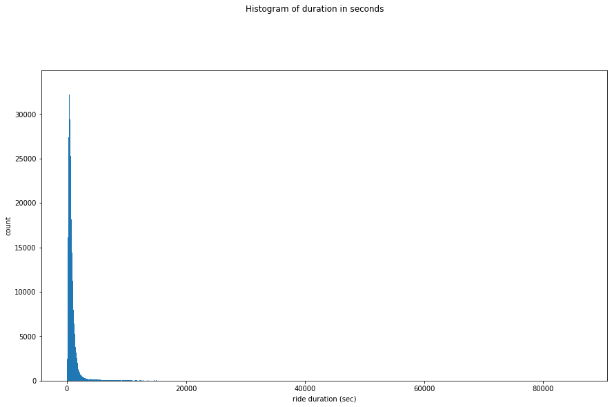

```python
# start with a standard-scaled plot
binsize = 50
bins = np.arange(0, data['duration_sec'].max()+binsize, binsize)

# define the base color to be used in most of the plots later
base_color = sb.color_palette()[0]

# define standard and panorama plot sizes --> the names of the variables i just created, they are not common
standard = [14.70, 8.27]
panorama = [20,8.27]
# plt.figure(figsize=[14.70, 8.27])

# create the plot
plt.figure(figsize=standard)
plt.hist(data = data, x = 'duration_sec', bins = bins)
plt.xlabel('ride duration (sec)')
plt.ylabel('count')
plt.suptitle("Histogram of duration in seconds", y = 1.04)
plt.show()
```

We can see that the data is skewed towards the left-side of the plot, we can trim the values bigger than 20,000 or use the log scale on the x-axis

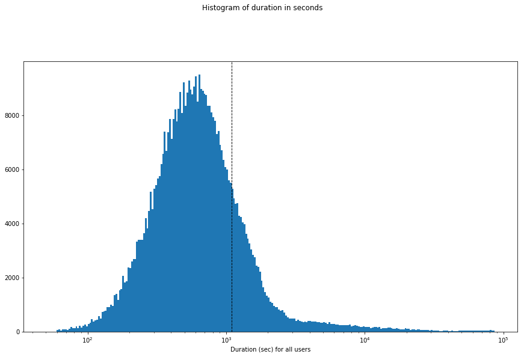

```python
# let's put the plot code inside a function so we can re-use it later
def plot_duration_log(data, msg):
    '''
    A function to plot a log scale histogram for the duration feature

    inputs:
        data : the dataframe that contain the duration column
        msg : the customized msg to be printed under the plot
    outputs:
        a log scale histogram for the duration column, with the msg sent, and the mean duration is printed.
    '''
    log_binsize = 0.0125

    # 1.7 is the log(minimum duration from the data-set)
    bins = 10 ** np.arange(1.7, np.log10(data['duration_sec'].max())+log_binsize, log_binsize)

    plt.figure(figsize=standard)
    plt.hist(data = data, x = 'duration_sec', bins = bins)
    plt.xscale('log')
    plt.xlabel('Duration (sec) '+msg)
    plt.axvline(data['duration_sec'].mean(), color='k', linestyle='dashed', linewidth=1)
    plt.suptitle("Histogram of duration in seconds", y = 1.04)
    plt.show()
#     print(" The mean of ride duration is  = ", data['duration_sec'].mean())
plot_duration_log(data, msg = 'for all users')
```

## Analysing the properties for customers and subsribers

Another variable in the data-set is differentiating the ride users into two types, **Cusomters** and **Subscribers**.

It will be interesting to see if the mean of ride duration differs in each group, how much difference, what are the trends in each group, so the company can offer different packages and offeres that well-suit each group, in order to achieve maximum user statisfaction and highest income.

```python
# create two subsets of the data-set depending on the user_type
customers = data[data['user_type']=='Customer']
subscribers =  data[data['user_type']=='Subscriber']
```

```python
# see some descriptive statistics for the numeric columns in the subscribers subset
subscribers.describe()
```

|  | duration_sec | start_station_id | start_station_latitude | start_station_longitude | end_station_id | end_station_latitude | end_station_longitude | bike_id |
| --- | --- | --- | --- | --- | --- | --- | --- | --- |
| count | 409230.000000 | 409230.000000 | 409230.000000 | 409230.000000 | 409230.000000 | 409230.000000 | 409230.000000 | 409230.000000 |
| mean | 705.310490 | 94.510280 | 37.771584 | -122.363852 | 91.065765 | 37.771669 | -122.363032 | 1686.480292 |
| std | 1852.582653 | 84.215033 | 0.085501 | 0.104678 | 82.359827 | 0.085391 | 0.104158 | 974.827223 |
| min | 61.000000 | 3.000000 | 37.317298 | -122.444293 | 3.000000 | 37.317298 | -122.444293 | 10.000000 |
| 25% | 350.000000 | 25.000000 | 37.773492 | -122.411647 | 24.000000 | 37.774520 | -122.409449 | 797.000000 |
| 50% | 529.000000 | 67.000000 | 37.782405 | -122.398436 | 66.000000 | 37.782411 | -122.397405 | 1746.000000 |
| 75% | 782.000000 | 137.000000 | 37.795001 | -122.391034 | 133.000000 | 37.795001 | -122.391034 | 2538.000000 |
| max | 86075.000000 | 340.000000 | 37.880222 | -121.874119 | 340.000000 | 37.880222 | -121.874119 | 3733.000000 |

```python
# see some descriptive statistics for the numeric columns in the customers subset
customers.describe()
```

|  | duration_sec | start_station_id | start_station_latitude | start_station_longitude | end_station_id | end_station_latitude | end_station_longitude | bike_id |
| --- | --- | --- | --- | --- | --- | --- | --- | --- |
| count | 110470.000000 | 110470.000000 | 110470.000000 | 110470.000000 | 110470.000000 | 110470.000000 | 110470.000000 | 110470.000000 |
| mean | 2557.445786 | 96.975242 | 37.771908 | -122.364204 | 96.326632 | 37.772491 | -122.363990 | 1620.866398 |
| std | 6355.311637 | 92.650209 | 0.089220 | 0.108827 | 93.892115 | 0.089239 | 0.108615 | 956.626188 |
| min | 61.000000 | 3.000000 | 37.317298 | -122.444293 | 3.000000 | 37.317298 | -122.444293 | 11.000000 |
| 25% | 667.000000 | 19.000000 | 37.773507 | -122.412544 | 16.000000 | 37.773793 | -122.411738 | 755.000000 |
| 50% | 1086.000000 | 67.000000 | 37.785881 | -122.402575 | 66.000000 | 37.786375 | -122.402923 | 1657.000000 |
| 75% | 1754.000000 | 148.000000 | 37.798014 | -122.391034 | 149.000000 | 37.799953 | -122.391198 | 2450.000000 |
| max | 86369.000000 | 340.000000 | 37.880222 | -121.874119 | 340.000000 | 37.880222 | -121.874119 | 3732.000000 |

For better understanding the nature of the data-set, its better to see the percentage of each group in the data-se.

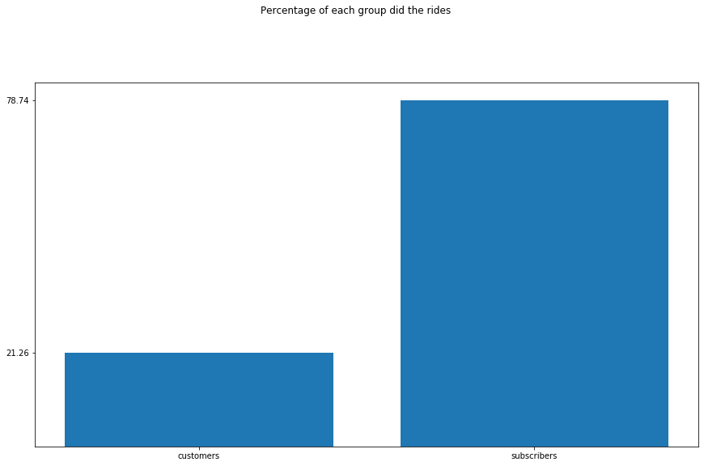

```python
# a list of group names and their percentage
types_numbers = [('customers', customers.shape[0]*100/ data.shape[0]), ('subscribers',subscribers.shape[0]*100/data.shape[0])]
labels, ys = zip(*types_numbers)
xs = np.arange(len(labels))
plt.figure(figsize=standard)
plt.bar(xs, ys, align='center' , color  = base_color)
plt.xticks(xs, labels) #Replace default x-ticks with xs, then replace xs with labels
plt.yticks(ys)
plt.suptitle('Percentage of each group did the rides', y = 1.04)
plt.show()
```

The plot says that subscribers are responsible for approxmaitly three quarters of the rides.

Let's see what is the mean ride duration of each group separetly

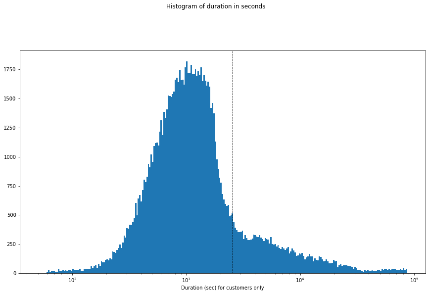

```python
plot_duration_log(customers, msg= 'for customers only')
```

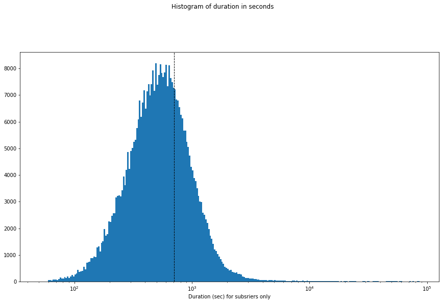

```python
plot_duration_log(subscribers, msg = 'for subsriers only')
```

The histograms showed that subscribers counts are higher, which we already know. But also, we can notice that the average of ride duration for subscribers is much lower than the average for the customers.  
But, what is the distribution of each group over the durations?. In other words, what is the percentage from each group that is responsible for each duration interval.

```
- Let us look at the numbers first to gain some intuition
```

```python
print('         CUSTOMERS')
print(customers['duration_sec'].describe())
print("-"*40)
print('         SUBSCRIBERS')
print(subscribers['duration_sec'].describe())
```

```
         CUSTOMERS
count    110470.000000
mean       2557.445786
std        6355.311637
min          61.000000
25%         667.000000
50%        1086.000000
75%        1754.000000
max       86369.000000
Name: duration_sec, dtype: float64
----------------------------------------
         SUBSCRIBERS
count    409230.000000
mean        705.310490
std        1852.582653
min          61.000000
25%         350.000000
50%         529.000000
75%         782.000000
max       86075.000000
Name: duration_sec, dtype: float64
```

The numbers suggestes that customers takes nearly double the duration of the subscribers for each quartile. The following violin plot to better see the distribution.

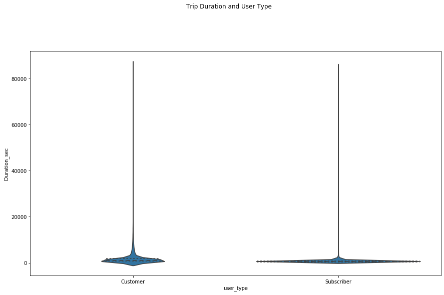

```python
plt.figure(figsize=standard)
sb.violinplot(data = data, x = 'user_type', y = 'duration_sec', color = base_color, inner='quartile')
plt.suptitle('Trip Duration and User Type', y = 1.04)
plt.ylabel('Duration_sec');
plt.show()
```

It looks like the outliers prevented the plot to be easily read. maybe plotting again after filtering the outliers is benefecial. For better see what limit should be trim at, lets convert the duration to minutes and hours.

```python
# create the duration in minutes column
data['dur_min'] = data['duration_sec'] /  60

# create the duration in hours column
data['dur_hour'] = data['duration_sec'] /  3600
```

```python
print('         MINUTES')
print(data['dur_min'].describe())
print("-"*40)
print('         HOURS')
print(data['dur_hour'].describe())
```

```
         MINUTES
count    519700.000000
mean         18.316825
std          57.402441
min           1.016667
25%           6.366667
50%           9.933333
75%          15.633333
max        1439.483333
Name: dur_min, dtype: float64
----------------------------------------
         HOURS
count    519700.000000
mean          0.305280
std           0.956707
min           0.016944
25%           0.106111
50%           0.165556
75%           0.260556
max          23.991389
Name: dur_hour, dtype: float64
```

Now, let's re-plot the violin plot in hours

# Duration of the rides for each group

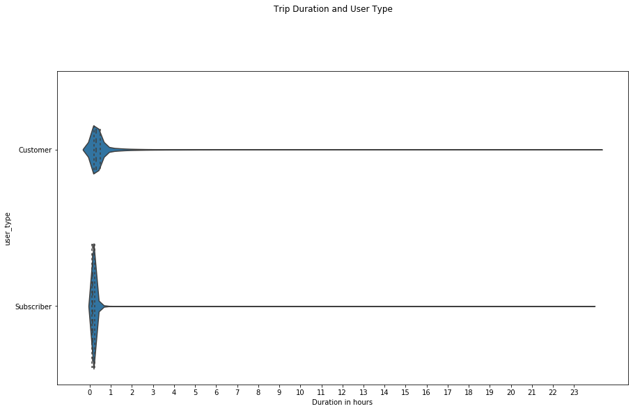

```python
plt.figure(figsize=standard)
sb.violinplot(data = data, y = 'user_type', x = 'dur_hour', color = base_color, inner='quartile')
plt.suptitle('Trip Duration and User Type', y = 1.04)
plt.xlabel('Duration in hours')
plt.xticks(range(0,24,1))
plt.show()
```

Now, its clear that there are some outliers that hurts our analysis. These outliers mainly fall in the fourth quartile, where the numbers of hours the ride took is lasting for nearly 1 day. That could be false values in the data collection or some fault made by the user for not closing the recording system for his ride. To better analyze the data, we should get rid of these outliers, as they barely happen in real life and do not reflect the everyday scenario.

```python
# select 99% of the data-set accodring to duration in hours feature --> remove the highest 1%
v_99 = data["dur_hour"].quantile(0.99)
data_filtered = data[data['dur_hour'] <= v_99]

data_filtered['dur_hour'].describe()
```

```
count    514503.000000
mean          0.230095
std           0.271792
min           0.016944
25%           0.105556
50%           0.164167
75%           0.256389
max           3.149722
Name: dur_hour, dtype: float64
```

```python
# describtion of the duration in minutes after removal of the highest 1%
data_filtered['dur_min'].describe()
```

```
count    514503.000000
mean         13.805712
std          16.307526
min           1.016667
25%           6.333333
50%           9.850000
75%          15.383333
max         188.983333
Name: dur_min, dtype: float64
```

From the previous numbers,we can removed the highest 1% values.

```
- For me, plotting the filtered data on the min scale is making the most sense between (seconds, minutes, hours)
```

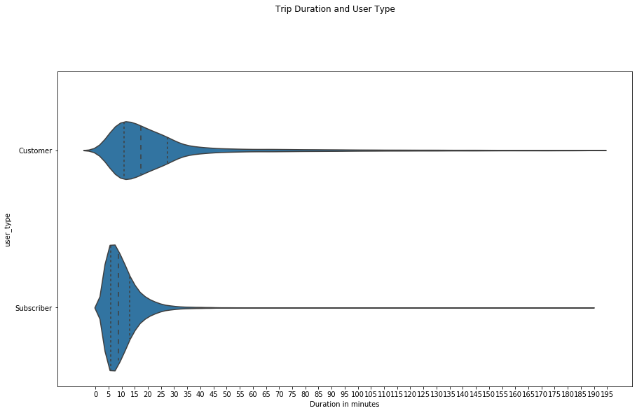

```python
plt.figure(figsize=standard)
sb.violinplot(data = data_filtered, y = 'user_type', x = 'dur_min', color = base_color, inner='quartile')
plt.suptitle('Trip Duration and User Type', y = 1.04)
plt.xlabel('Duration in minutes')
plt.xticks(range(0,200,5))
plt.show()
```

We can conclude that the biggest group of subscribers are more directed for their rides (between 5 and 10 mins), not like customers that tend to take long rides. Which make most sense, as the person who subscribes would do that only if he is regular bike user for some commute for work or home. However, long rides subscribers maybe the ones who do that for sports or far from work, which we can then direct them by some offers to increase that group of subscrobers.

However, some facts about customers :

```
    - 75% of the customers take the ride for more than 10 mins.
    - 50% of the customers spend between 10 min and 30 mins.
    - 25% of the customers last for more than 30 mins.
```

# Timing of the rides in each day for subscribers

```python
# Change start_time and end_time to datetime format
data.start_time = pd.to_datetime(data.start_time)
data.end_time = pd.to_datetime(data.end_time)

# Extract dayofweek, hours information from the start_time
data['day']= data['start_time'].dt.strftime('%a')
data['hour']= data['start_time'].dt.hour

data.head(5)
```

|  | duration_sec | start_time | end_time | start_station_id | start_station_name | start_station_latitude | start_station_longitude | end_station_id | end_station_name | end_station_latitude | end_station_longitude | bike_id | user_type | dur_min | dur_hour | day | hour |
| --- | --- | --- | --- | --- | --- | --- | --- | --- | --- | --- | --- | --- | --- | --- | --- | --- | --- |
| 0 | 80110 | 2017-12-31 16:57:39.654 | 2018-01-01 15:12:50.245 | 74 | Laguna St at Hayes St | 37.776435 | -122.426244 | 43 | San Francisco Public Library (Grove St at Hyde... | 37.778768 | -122.415929 | 96 | Customer | 1335.166667 | 22.252778 | Sun | 16 |
| 1 | 78800 | 2017-12-31 15:56:34.842 | 2018-01-01 13:49:55.617 | 284 | Yerba Buena Center for the Arts (Howard St at ... | 37.784872 | -122.400876 | 96 | Dolores St at 15th St | 37.766210 | -122.426614 | 88 | Customer | 1313.333333 | 21.888889 | Sun | 15 |
| 2 | 45768 | 2017-12-31 22:45:48.411 | 2018-01-01 11:28:36.883 | 245 | Downtown Berkeley BART | 37.870348 | -122.267764 | 245 | Downtown Berkeley BART | 37.870348 | -122.267764 | 1094 | Customer | 762.800000 | 12.713333 | Sun | 22 |
| 3 | 62172 | 2017-12-31 17:31:10.636 | 2018-01-01 10:47:23.531 | 60 | 8th St at Ringold St | 37.774520 | -122.409449 | 5 | Powell St BART Station (Market St at 5th St) | 37.783899 | -122.408445 | 2831 | Customer | 1036.200000 | 17.270000 | Sun | 17 |
| 4 | 43603 | 2017-12-31 14:23:14.001 | 2018-01-01 02:29:57.571 | 239 | Bancroft Way at Telegraph Ave | 37.868813 | -122.258764 | 247 | Fulton St at Bancroft Way | 37.867789 | -122.265896 | 3167 | Subscriber | 726.716667 | 12.111944 | Sun | 14 |

Inspect the distribution of the hours when the rides happen

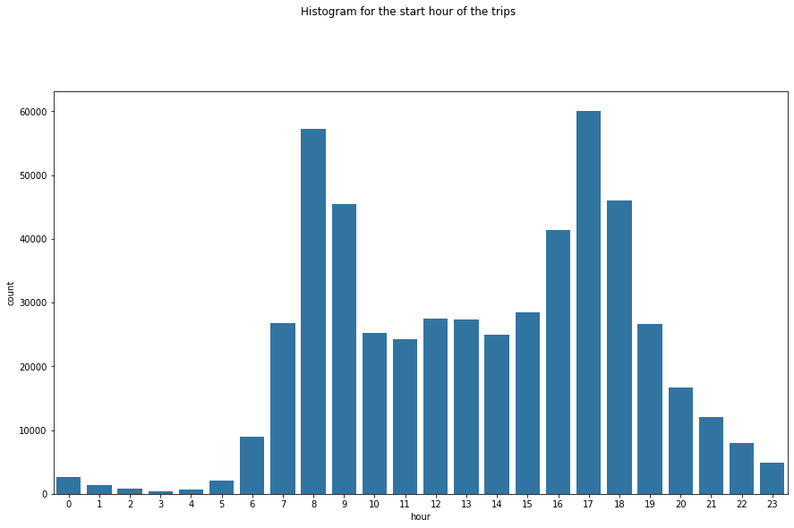

```python
plt.figure(figsize=standard)
plt.suptitle('Histogram for the start hour of the trips', y = 1.04)
sb.countplot(data = data , x = 'hour', color = base_color);
```

There are two peaks, at 8 AM and 5 PM.

**Hypothesis**

```
      - maybe the two peaks come from the subcribers who are going to and from work, and that wouldn't be the same case in holidays ?
```

To check this hypothesis: let's see the distribution of suscribers and customers over the day.

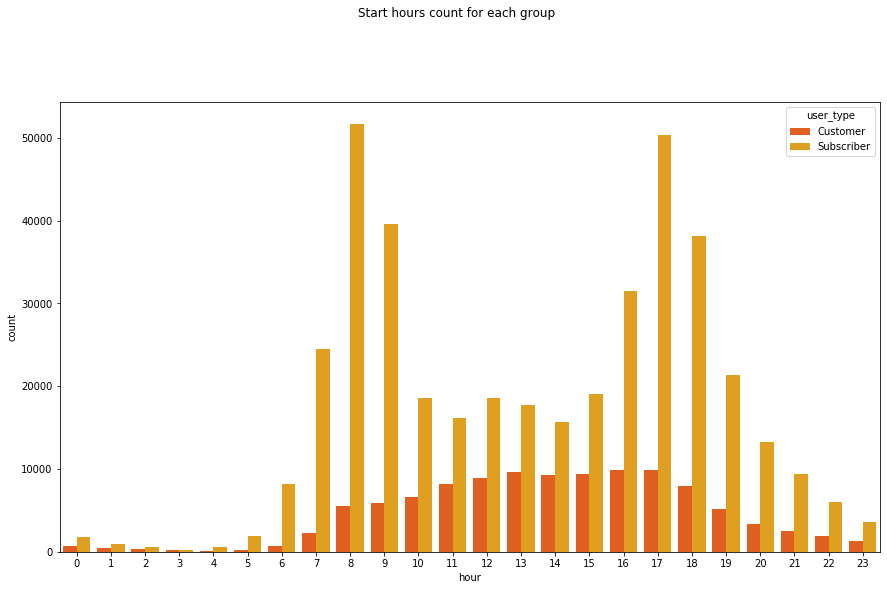

```python
plt.figure(figsize=standard)
plt.suptitle('Start hours count for each group', y = 1.04)
sb.countplot(data = data, x = 'hour', hue = 'user_type', palette = 'autumn''');
```

As expected, the peaks are coming from subscribers and do not appear in customers side.

Let's further investigate if the two peaks appears for all the week days for the subscribers.

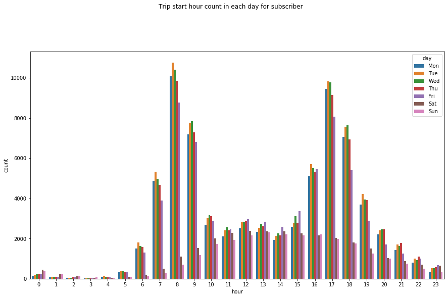

```python
# extract the subscribers only
subscribers = data[data['user_type'] == 'Subscriber']
#define the order of days to be plotted in order
day_order =['Mon','Tue','Wed','Thu','Fri','Sat','Sun']
# plot the subset against hours and days
plt.figure(figsize=standard)
plt.suptitle('Trip start hour count in each day for subscriber', y = 1.04)
sb.countplot(data = subscribers, x = 'hour', hue = 'day', hue_order = day_order);
```

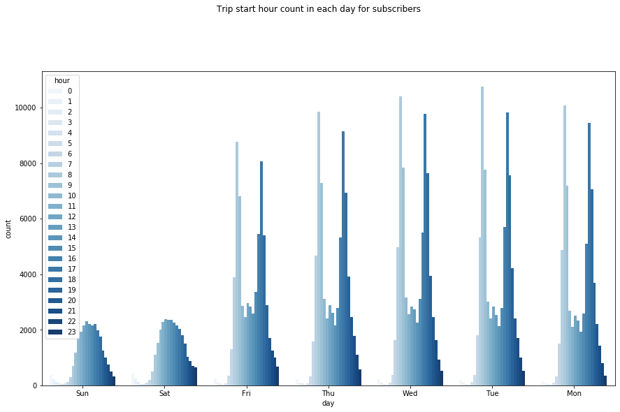

```python
# The same plot with reversing the hour and day, plotting both to see which is better to be presented!
plt.figure(figsize=standard)
plt.suptitle('Trip start hour count in each day for subscribers', y = 1.04)
sb.countplot(data = subscribers, hue = 'hour', x = 'day', palette = 'Blues');
```

Two peaks appears in all days are not appearing in sundays and saturdays. Mostly the two peaks come from the subcribers who are going to and from work, and its no the same case in holidays. Therfore, we can target people going to work and still not using the bikes with interesting offers.

We can accept the hypothesis ;).

Now, let's see the distribution of all the rides on the days

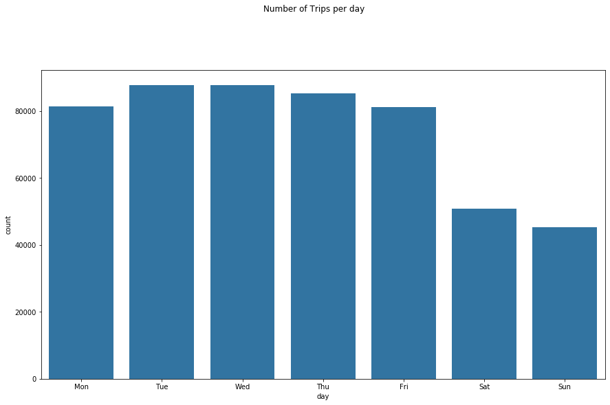

```python
plt.figure(figsize=standard)
plt.suptitle('Number of Trips per day', y = 1.04)
sb.countplot(data = data , x = 'day', color = base_color, order = day_order);
```

And the distribution of the two groups of the user types in each day.

# Day of the ride for each group

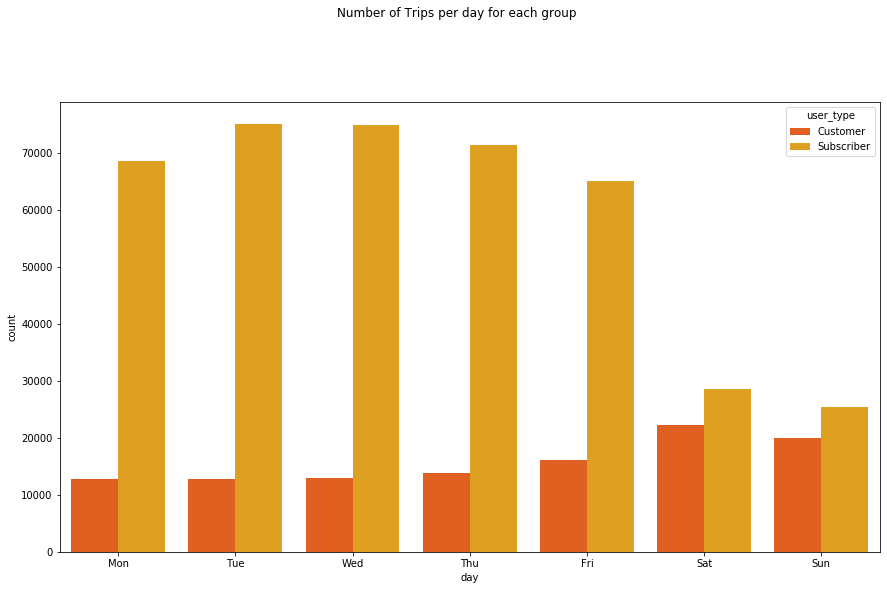

```python
plt.figure(figsize=standard)
plt.suptitle('Number of Trips per day for each group', y = 1.04)
sb.countplot(data = data, x = 'day', hue = 'user_type', palette = 'autumn', order = day_order);
```

The subscribers are much lower in the holidays as we previously concluded. However, the customers are the highest at holidays. We can make use of this fact and address the customers with special offers for holidays to increase the number of rides.